# Finding a vaccination appointment analyzing the impfstoffbot account

Finding a vaccine in Berlin has been a challenging task. Many different tools to check the availability of appointments in the different vaccination centers area available online. I was frustrated because I couldn't find an appointment for my girlfriend and me on doctolib.com, so I did some analysis on the service by impfstoff.link. Using the twitter API, I downloaded the tweet history of the bot and analyzed the data. I learned what were the times of the day where the service was most updated, how long in the future would the appointment be, and some characteristics of the different vaccination centers. I am proud to say that I got a vaccination appointment for the next weeks using the data I learned.

This notebook analyzes the tweet history of the account @impfstoffbot until 05.06.2021 to try to answer the following questions:

- Where in Berlin am I most likely to get the vaccine?
- What time of the day am I most likely to find a vaccination appointment?
- What is the date where my appointment will happen?

```python
import pandas as pd
import matplotlib.pyplot as plt
pd.set_option('display.max_rows', 50)
plt.rcParams["figure.figsize"] = (12,7)
graph_color = 'royalblue'
```

## Data Preporcessing

```python
data = pd.read_csv('impfstoffbot2.csv')
data
```

|  | Text | UTC |
| --- | --- | --- |
| 0 | ?? Available slots found at Messe Berlin on 10... | 2021-06-05T08:40:17.000Z |
| 1 | ?? Available slots found at Messe Berlin on 9.... | 2021-06-05T08:37:37.000Z |
| 2 | ?? Available slots found at Messe Berlin on 3.... | 2021-06-05T08:25:37.000Z |
| 3 | ?? Available slots found at Messe Berlin on 8.... | 2021-06-05T08:08:27.000Z |
| 4 | ?? Available slots found at Messe Berlin on 7.... | 2021-06-05T08:03:57.000Z |
| ... | ... | ... |
| 1447 | ?? Appointments on Erika-He�-Eisstadion availa... | 2021-05-12T02:32:40.000Z |
| 1448 | ?? Appointments on Flughafen Berlin-Tegel avai... | 2021-05-12T02:18:21.000Z |
| 1449 | ?? Appointments on Flughafen Berlin-Tegel avai... | 2021-05-12T02:15:45.000Z |
| 1450 | ?? Appointments on Flughafen Berlin-Tegel avai... | 2021-05-12T01:48:54.000Z |
| 1451 | ?? Appointments on Flughafen Berlin-Tegel avai... | 2021-05-12T01:44:55.000Z |

1452 rows × 2 columns

```python
# filter informative tweets

data['is_appointment'] = data['Text'].apply(lambda x: True if x[0:2] == '??' else False)
```

```python
# non-informative tweets
data[data['is_appointment'] == False]
```

```python
# only use informative tweets
data = data[data['is_appointment'] == True].copy()
```

```python
# format datetime data
data['UTC'] = pd.to_datetime(data['UTC'], infer_datetime_format=True)
```

```python
data['UTC'].dtypes
```

```
datetime64[ns, UTC]
```

```python
# get locations in tweets

def get_location(text):
    locations = ['Messe Berlin',
             'Flughafen Tempelhof',
             'Flughafen Berlin-Tegel',
             'Velodrom Berlin',
             'Erika-He�-Eisstadion',
             'Arena Berlin',
            ]

    for loc in locations:
        if loc in text:
            return loc
    return 'not in list'
```

```python
# make sure that all tweets have valid locations

data['location'] = data['Text'].apply(lambda text: get_location(text))
data[data['location'] == 'not in list']
```

|  | Text | UTC | is_appointment | location |
| --- | --- | --- | --- | --- |

```python
# format time of appintment

data['time_of_appointment'] = data['Text'].str.extract('(\d+.\d+.\d+)')
data['time_of_appointment'] = pd.to_datetime(data['time_of_appointment'], format='%d.%m.%Y')
data['time_of_appointment'] = data['time_of_appointment'].apply(lambda x : x.tz_localize('Europe/Berlin'))
```

```python
# transform UTC in berlin time. This is time tweet was posted

data['Berlin_time'] = data['UTC'].dt.tz_convert('Europe/Berlin')
```

```python
# extract data from posted tweet time

data['posted_hour'] = data['Berlin_time'].apply(lambda x : x.hour)
data['posted_min'] = data['Berlin_time'].apply(lambda x : x.minute)
data['posted_sec'] = data['Berlin_time'].apply(lambda x : x.second)
```

```python
# used to analyze month and day sequence

data['posted_month_day'] = data['Berlin_time'].apply(lambda x : pd.to_datetime(str(x.day) + '/' + str(x.month) +'/2021', format='%d/%m/%Y'))
```

```python
# used to grouop by hour an minute

data['posted_hour_min'] = data.apply(lambda row: row['posted_hour'] + round(row['posted_min']/60,1), axis=1)
```

```python
# final data

data.head()
```

|  | Text | UTC | is_appointment | location | time_of_appointment | Berlin_time | posted_hour | posted_min | posted_sec | posted_month_day | posted_hour_min |
| --- | --- | --- | --- | --- | --- | --- | --- | --- | --- | --- | --- |
| 0 | ?? Available slots found at Messe Berlin on 10... | 2021-06-05 08:40:17+00:00 | True | Messe Berlin | 2021-07-10 00:00:00+02:00 | 2021-06-05 10:40:17+02:00 | 10 | 40 | 17 | 2021-06-05 | 10.7 |
| 1 | ?? Available slots found at Messe Berlin on 9.... | 2021-06-05 08:37:37+00:00 | True | Messe Berlin | 2021-07-09 00:00:00+02:00 | 2021-06-05 10:37:37+02:00 | 10 | 37 | 37 | 2021-06-05 | 10.6 |
| 2 | ?? Available slots found at Messe Berlin on 3.... | 2021-06-05 08:25:37+00:00 | True | Messe Berlin | 2021-07-03 00:00:00+02:00 | 2021-06-05 10:25:37+02:00 | 10 | 25 | 37 | 2021-06-05 | 10.4 |
| 3 | ?? Available slots found at Messe Berlin on 8.... | 2021-06-05 08:08:27+00:00 | True | Messe Berlin | 2021-07-08 00:00:00+02:00 | 2021-06-05 10:08:27+02:00 | 10 | 8 | 27 | 2021-06-05 | 10.1 |
| 4 | ?? Available slots found at Messe Berlin on 7.... | 2021-06-05 08:03:57+00:00 | True | Messe Berlin | 2021-07-07 00:00:00+02:00 | 2021-06-05 10:03:57+02:00 | 10 | 3 | 57 | 2021-06-05 | 10.1 |

```python
gb_loc = data.groupby('location')['location'].count()
gb_loc
```

```
location
Arena Berlin              160
Erika-He�-Eisstadion      229
Flughafen Berlin-Tegel    288
Flughafen Tempelhof       147
Messe Berlin              435
Velodrom Berlin           182
Name: location, dtype: int64
```

## Data Analysis

### General Trend

The first thing i wanted to see is the general behavior of the bot. I want to see first how often is the bot updated.

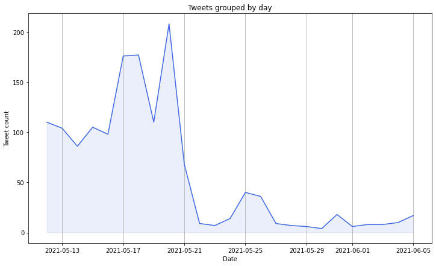

```python
gb_date = data.groupby('posted_month_day')['location'].count()

to_plot = gb_date

plt.plot(to_plot.index, to_plot.values, color=graph_color)
plt.fill_between(to_plot.index, to_plot.values, color=graph_color, alpha=0.1)
plt.locator_params(axis="x", nbins=5)
plt.grid(axis="x")

plt.title('Tweets grouped by day')
plt.xlabel('Date')
plt.ylabel('Tweet count')
```

The bot was updated much more often before, but we can see that there is at least one tweet every day. The assuption of the project is then that at the same time that the bot tweets, the service in https://impfstoff.link/ is updated, and therefore there is an available appointment.

The next question is: where in Berlin am I more likely to get an appointment?

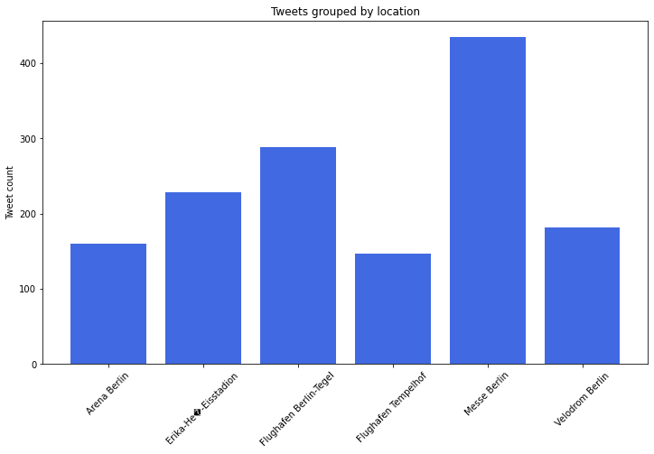

```python
plt.bar(gb_loc.index, gb_loc.values, color=graph_color)
# plt.grid(axis="x")
plt.xticks(rotation = 45)
plt.ylabel('Tweet count')
plt.title('Tweets grouped by location')
```

Messe Berlin and Flughafen Tegel have by far the most appointments available historically, sometimes double or triple the amount of other sites.

Now to the useful part. I don't want to sit on my computer all day refreshing the page aimlessly. So, at what time during the day am I most likely to find an appointment?

```python
gb_hour = data.groupby(['posted_hour'])['location'].count()
```

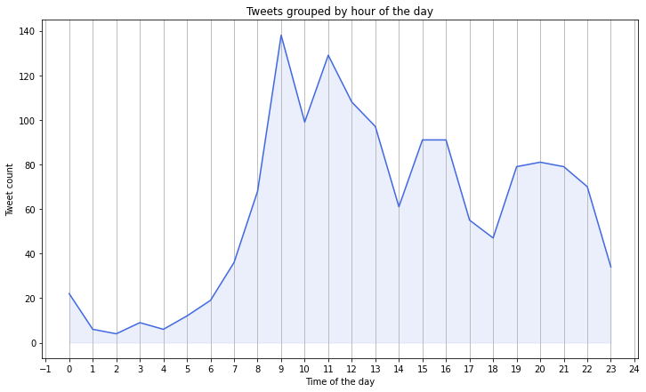

```python
to_plot = gb_hour

plt.plot(to_plot.index, to_plot.values, color=graph_color)
plt.fill_between(to_plot.index, to_plot.values, color=graph_color, alpha=0.1)
plt.locator_params(axis="x", nbins=30)
plt.grid(axis="x")

plt.title('Tweets grouped by hour of the day')
plt.xlabel('Time of the day')
plt.ylabel('Tweet count')
```

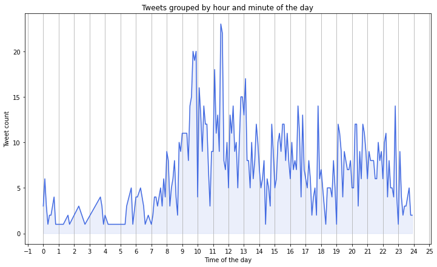

```python
gb_hour_min = data.groupby(['posted_hour_min'])['location'].count()

to_plot = gb_hour_min

plt.plot(to_plot.index, to_plot.values,color=graph_color)
plt.fill_between(to_plot.index, to_plot.values, color=graph_color, alpha=0.1)
plt.locator_params(axis="x", nbins=30)
plt.grid(axis="x")

plt.title('Tweets grouped by hour and minute of the day')
plt.xlabel('Time of the day')
plt.ylabel('Tweet count')
```

More specifically, grouping by hour and minute of the day, the peak seems to stay at around 11:30am, with much more visible activiy during the day and evening than during the night. Midday still seems the bast time to sit on the computer and search.

### Trends in specific places

Messe Berlin andn Flughafel Tegel are the locations closest to my home, so I want to see what are the best moments in the day to get an appointment there.

```python
gb_loc_hour = data.groupby(['location', 'posted_hour'])['location'].count()
gb_loc_hour
```

```
location         posted_hour
Arena Berlin     0               5
                 1               1
                 2               2
                 4               1
                 5               1
                                ..
Velodrom Berlin  19              8
                 20              7
                 21             15
                 22              9
                 23              5
Name: location, Length: 127, dtype: int64
```

### Messe Berlin

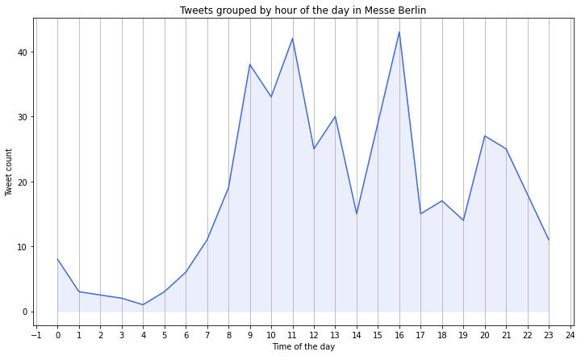

```python
to_plot = gb_loc_hour['Messe Berlin']

plt.plot(to_plot.index, to_plot.values,color=graph_color)
plt.fill_between(to_plot.index, to_plot.values, color=graph_color, alpha=0.1)
plt.locator_params(axis="x", nbins=30)
plt.grid(axis="x")

plt.title('Tweets grouped by hour of the day in Messe Berlin')
plt.xlabel('Time of the day')
plt.ylabel('Tweet count')
```

```python
gb_loc_hm = data.groupby(['location', 'posted_hour_min'])['location'].count()
gb_loc_hm
```

```
location         posted_hour_min
Arena Berlin     0.0                1
                 0.1                2
                 0.4                1
                 0.5                1
                 1.1                1
                                   ..
Velodrom Berlin  23.0               1
                 23.3               2
                 23.4               1
                 23.7               1
                 23.9               1
Name: location, Length: 658, dtype: int64
```

```python
data[(data['location']=='Arena Berlin') & (data['posted_hour_min']==0)]
```

[output not shown]

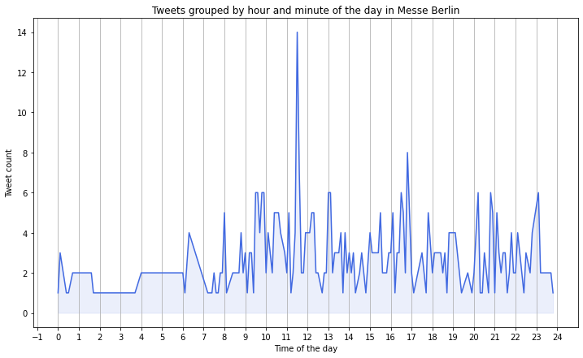

```python
gb_loc_hm

# plt.plot(gb_loc_hm['Messe Berlin'].index, gb_loc_hm['Messe Berlin'].values)
# plt.locator_params(axis="x", nbins=30)
# plt.grid(axis="x")

to_plot = gb_loc_hm['Messe Berlin']

plt.plot(to_plot.index, to_plot.values,color=graph_color)
plt.fill_between(to_plot.index, to_plot.values, color=graph_color, alpha=0.1)
plt.locator_params(axis="x", nbins=30)
plt.grid(axis="x")

plt.title('Tweets grouped by hour and minute of the day in Messe Berlin')
plt.xlabel('Time of the day')
plt.ylabel('Tweet count')
```

Messe Berlin follows the general trend, and especially since it is the location with most appointments, this was expected. There is a peak at aroudn 11:30, so this time is still the best time to look at.

```python
gb_loc_hm['Messe Berlin'][gb_loc_hm['Messe Berlin'] > 2]
```

```
posted_hour_min
0.1     3
6.3     4
8.0     5
8.8     4
9.0     3
       ..
21.8    4
22.1    4
22.5    3
22.8    4
23.1    6
Name: location, Length: 72, dtype: int64
```

### Flughafen Berlin-Tegel

Tegel is a bit different, as the morning peak happens at around 9am. When grouping by minute and hour, we can observe that this peak is distributed during the whole hour, so it may be a good idea to look at any minute at 9am.

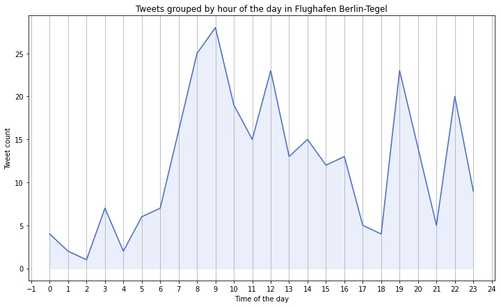

```python
# plt.plot(gb_loc_hour['Flughafen Berlin-Tegel'].index, gb_loc_hour['Flughafen Berlin-Tegel'].values)
# plt.locator_params(axis="x", nbins=30)
# plt.grid(axis="x")

to_plot = gb_loc_hour['Flughafen Berlin-Tegel']

plt.plot(to_plot.index, to_plot.values,color=graph_color)
plt.fill_between(to_plot.index, to_plot.values, color=graph_color, alpha=0.1)
plt.locator_params(axis="x", nbins=30)
plt.grid(axis="x")

plt.title('Tweets grouped by hour of the day in Flughafen Berlin-Tegel')
plt.xlabel('Time of the day')
plt.ylabel('Tweet count')
```

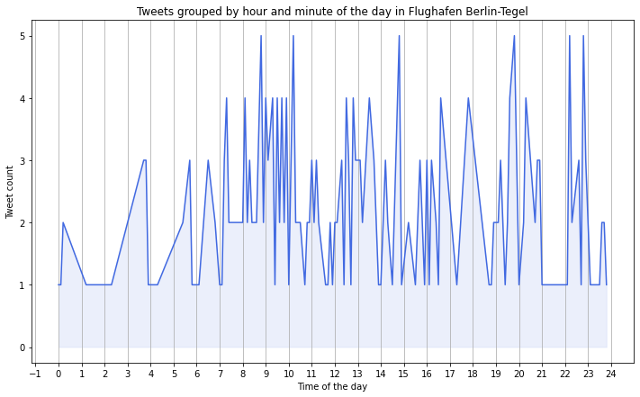

```python
to_plot = gb_loc_hm['Flughafen Berlin-Tegel']

plt.plot(to_plot.index, to_plot.values,color=graph_color)
plt.fill_between(to_plot.index, to_plot.values, color=graph_color, alpha=0.1)
plt.locator_params(axis="x", nbins=30)
plt.grid(axis="x")

plt.title('Tweets grouped by hour and minute of the day in Flughafen Berlin-Tegel')
plt.xlabel('Time of the day')
plt.ylabel('Tweet count')
```

```python
gb_loc_hm['Flughafen Berlin-Tegel'][gb_loc_hm['Flughafen Berlin-Tegel'] > 2]
```

[output not shown]

### Minute analysis

The update hours don't seem to follow any specific pattern. A person may be responsible to update the times whenever more vaccines are available, or there may be a complex scheduling scheme to make appointment booking truly random. But I'm guessing if there is a trend in the minutes (7:35, 8:35, 9:35, etc.) in case there is a scheduling system:

```python
gb_m = data.groupby(['posted_min'])['location'].count()
```

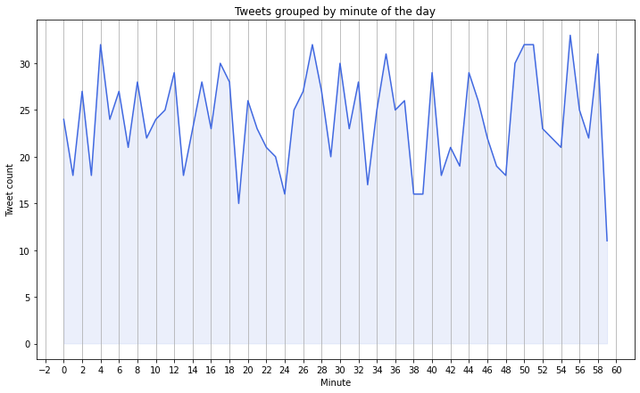

```python
to_plot = gb_m

plt.plot(to_plot.index, to_plot.values,color=graph_color)
plt.fill_between(to_plot.index, to_plot.values, color=graph_color, alpha=0.1)
plt.locator_params(axis="x", nbins=60)
plt.grid(axis="x")

plt.title('Tweets grouped by minute of the day')
plt.xlabel('Minute')
plt.ylabel('Tweet count')
```

There doesn't seem to be a best minute of the day to look fo vaccines.

## When will my appointment occur

The tweets contain the information of when will the available appoitnments happen. Getting some statistics of the time difference between the tweeted time of appointment and the actual time where the tweet was posted, we can gather some information:

```python
data['time_diff'] = data['time_of_appointment'] - data['Berlin_time']
```

```python
data['time_diff_days'] = data['time_diff'].apply(lambda x: x.days)
```

In general, it seems that the average waiting time between the tweet and the appointment is 31 days, but having a standart deviation of 24 means that the data varies a lot. This is confirmed by havig a maximum waiting time of 80 day, and minimum of 1, where you would get an appointment for the next day.

```python
print('mean:', data['time_diff_days'].mean())
print('std: ', data['time_diff_days'].std())
print('max: ', data['time_diff_days'].max())
print('min: ', data['time_diff_days'].min())
```

```
mean: 31.906315058986813
std:  24.82483569002583
max:  80
min:  1
```

In Messe Berlin, the mean and std waiting time are lower. This seems a good location to get vaccinated.

```python
loc = 'Messe Berlin'

print('mean:', data[data['location'] == loc]['time_diff_days'].mean())
print('std: ', data[data['location'] == loc]['time_diff_days'].std())
print('max: ', data[data['location'] == loc]['time_diff_days'].max())
print('min: ', data[data['location'] == loc]['time_diff_days'].min())
```

```
mean: 20.22758620689655
std:  13.222874064970073
max:  74
min:  2
```

Flughafen Berlin-Tegel has a mean waiting time of 71 days, with a very low std. This means that likely I will get an appointment far in the future if I book here.

```python
loc = 'Flughafen Berlin-Tegel'

print('mean:', data[data['location'] == loc]['time_diff_days'].mean())
print('std: ', data[data['location'] == loc]['time_diff_days'].std())
print('max: ', data[data['location'] == loc]['time_diff_days'].max())
print('min: ', data[data['location'] == loc]['time_diff_days'].min())
```

```
mean: 71.96527777777777
std:  3.877772258991688
max:  80
min:  60
```